# Canal Escoadouro - Teoria

Dimensionamento e Cálculo de Canais Escoadouros  
Bioengenharia de Solos

Luiz Diego Vidal Santos

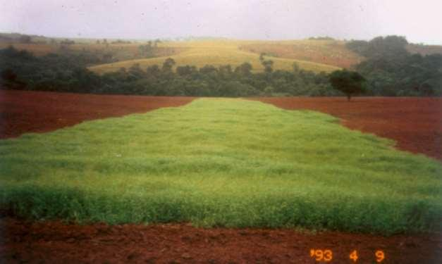

Canal Escoadouro - Teoria

**Disciplina: anejo e Conservação da gua e do Solo**

**Controle de Erosão Hídrica -**

**Clculo de Canal Escoadouro - Terraços em Gradiente**

| UNIVERSIDADE FEDERAL DE SERGIPE - UFS

## CANAISESCOADOUROS

**Definição: O canal escoadouro é um canal dedimensões apropriadas, rasos e largos, geralmente de pequena declividade e com leito resistente àerosão**

**Finalidade: Receber gua dos terraços com gradiente e transport-la para fora da rea sem causar problemas de erosão nos terrenos por ondepassa.**

**Tipos de canal escoadouro: Escoadouro Naturale**

**EscoadouroArtificial**

## Registros de campo: canais escoadouros

[figure not shown]

Escavação de canal escoadouro em área rural — conformação da seção trapezoidal com maquinário

[figure not shown]

Escavação e abertura de canal para condução do escoamento — etapa de implantação

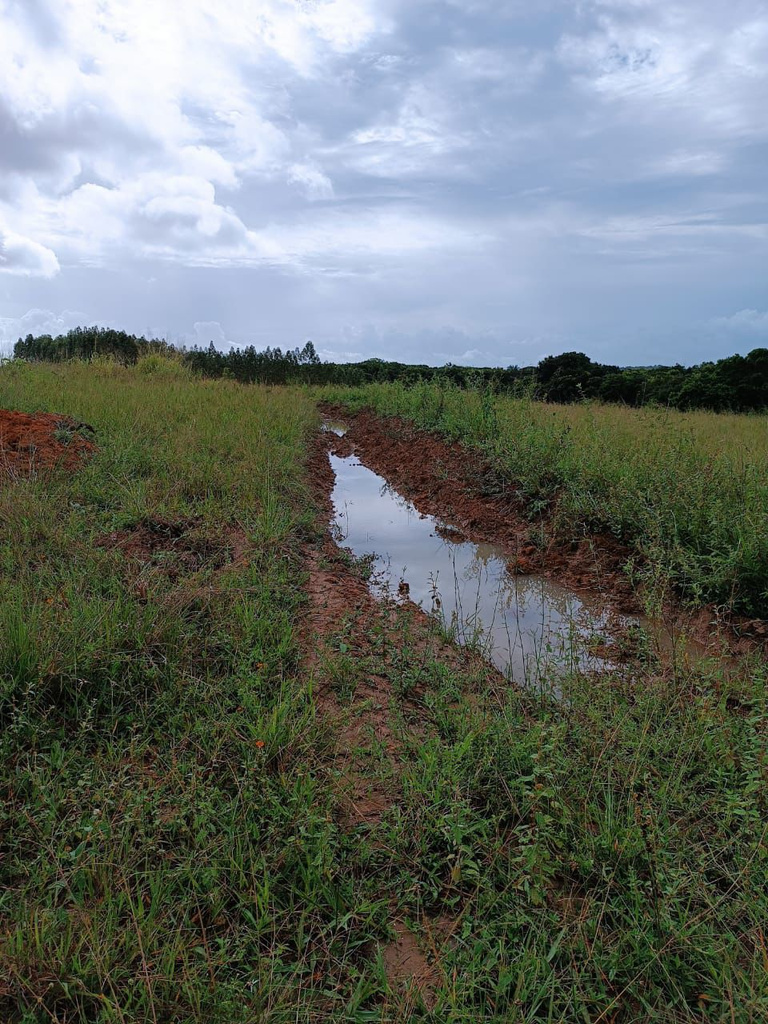

Localização do CanalEscoadouro

Características da vegetação de revestimento do CanalEscoadouro

**- Ser de fcilestabelecimento;**

**- Ser rustica e de crescimentorpido;**

**- Dar cobertura completa e uniforme ao solo;e**

**- Não ser daninha, nem hospedeira de pragas edoenças**

**ESPECIES**

**Revestimento docanal:**

**Grama batatais; Capim quicuiu; gengibre; rodes;centrosema;**

**kudzu comum ou kudzutropical;**

**Barreiras ou Dissipadores deenergia**

**Cana-de-açucar; capim-limão; capimelefante**

## Clculo do CanalEscoadouro

**Revestimento do canal escoadouro: Gramíneas de densidade média com estande ótimo**

**1° Passo:**

**Calcular EspaçamentoVertical**

**EV =( (D/X) + 2) x 0,305(Bentley)**

**EV= ((10/3,5))x0,305 = 1,46m, se D=(EV/EH) x 100,então:**

**EH =14,60m,**

**Logo:**

**200/14,60 = 14terraços**

## 2° Passo:

**Determinar o volume (vazão) de gua escoado pelocanal.**

**Qmax=**

𝑪𝑰𝑨

𝟑𝟔𝟎

**Emque:**

**Q = Vazão do canal escoadouro , emm³.**𝒔−𝟏**;**

**C= Coeficiente deenxurrada;**

**I = intensidade de chuva (**𝒎𝒎𝒉−𝟏);𝒆

**A=Áreadecontribuiçãodeenxurradaparaoterraço(rea**

**acima dele)(m²).**

ÁREA DO TERRAÇO 1 = 500 X 14,60 = 7.300 **m²** =0,73ha

VAZÃO DO TERRAÇO 1=

Q1 =CIA/360

Q1 = (0,58 x 190 x0,73)/360

**Q1 = 0,22m³.**𝒔−𝟏

**CALCULO PARA CADA TERRAÇOINDIVIDUALENTE**

**Considerando todos os terraços com mesmo comprimento e largura, então: A1=A2=A3=A4=A5=A6**

**Se “C” e “I”, permanecem constante,então:**

**Q2= Q1 + Q1, logo Q2=2Q1 = 2 x 0,22 = 0,44 m³.**𝒔−𝟏**,então**

**Q3 = 3 Q1 = 0,66m³.**𝒔−𝟏

**Então: 14 Q1 = 3,08m³.**𝒔−𝟏

## 3° Passo:

**Calcular a seção docanal.**

**Q = S xV**

**Em que:**

**Q = Vazão, volume de gua a ser escoado(m³**𝒔−𝟏**);**

**V = Velocidade mxima permitida dentro do canal(m³**𝒔−𝟏**);**

**S = Área da seção(m²)**

**Então,se**

**Q = S xV,**

**logo**

**Conhecendo-se Q1, Q2, Q3, Q4, Q5 e Q6, e sendo V=1,35m.**𝒔−𝟏

**S1 = 0,22/1,35,então**

**S1 = 0,16m²,**

**S2 = Q2/V = 0,32 m2, e assim sucessivamente até o 14ºterraço:**

**S14 = Q14/V = 2,24m²**

**Se h =0,25m e Y = 2h, tem-seque**

**A = (( B + b)/2) xh**

**S = Q/V**

**Calculando B1 e b1 para o 1º.Terraço**

B = b + 4h , B = b + 4 x 0,25, então B = b +1

Substituindo“B”por “b + 1” e tendo S1 = 0,16 **m2** , se **S = ((b + 1 + b)/2) xh**

então:

0,16 = ((b + 1 + b)/2) x 0,25, então **b1 =0,14**,

Desse modo se B = b + 1, então B = 0,14 + 1= **B1 =1,14**

**Para o segundo terraço, S2=0,32, logo 0,32 = ((b+1+b)/2) x 0,25 Então : b2=0,78 e B2=1,78**

**E assim são calculadas as bases maior e menor até o 14º terraço, ou seja:**

**S14= 2,24**

**2,24 = ((b+1+b)/2) x 0,25, então b14= 8,46 e B14=9,46**

**“b”**

**“B”**

S12

S2

S3

S4

S5

S6

S7

S8

S9

S10

S11

S1

S13

S14

Q1

Q2=2Q1

Q3=3Q1

Q4=4Q1

Q5=5Q1

Q6=6Q1

Q7=7Q1

Q8=8Q1

Q9=9Q1

Q10=10Q1

Q11=11Q1

Q12=12Q1

Q13=13Q1

Q14=14Q1

## LOCAÇÃO

** DE ESTACAS**

## 4° Passo:

**Calcular a velocidade daenxurrada**:

Para calcular a velocidade da enxurrada, emprega-se a fórmula propostapor**anning:**

𝑹𝟐/𝟑𝒙𝑰𝟏/𝟐

**V =** 𝒏

Emque:

V = Velocidade média da enxurrada (m𝑠−1);

R = Raio hidrulico(m);

I = Declividade do canal ( m 𝑚−1);e

n = coeficiente derugosidade.

O **Raio hidrulico** (R) pode ser obtido em quadros, porém, como no exemplo o canal escoadouro não possui seção uniforme em toda sua extensão, essa informação deve ser obtida através da formula:

𝐴

Em que:

R = Raio hidrulico (m);

A = S = Áreada seção transversaldocanal

A=((B+b)/2)xh;

P = Perímetro molhado(m).

O **Perímetro olhado** , por sua vez é obtido pelafórmula:

**P = b+2h√**𝟏+𝒁𝟐

Emque:

**P = Perímetro molhado(m);**

**b = Base menor(m);**

**h = Altura (m);e**

**Z = Talude, sendo que**:

**Z=Y/h**

Então, como Y = 2h, Zser:

Z=Y/h = 2h/h = 2x0,25/0,25 = 2,logo,

P = b + 2h√5,então

P1 = 0,14 +2 x 0,25 √5 =P1=1,26

P2 = 0,78 + 2 x 0,25 √5 = P2 = 1,90, Então P14= 8,46 + 0,25 √5 = P14 =9,58

Os **Raios Hidrulicos**serão:

𝑨

**R =**

E assim até o ultimo terraço, em que seteria:

R1= A1/P1….Rn = Na/Pn

Então:

**E assim até o 14º terraço = R14=A14/P14=2,24/9,58 = R14 =0,234**

Considerando:

n=0,100

I=6% = 0,06m.m-1, então I½ =0,2449,

Aplicandona Formula deanningteremos:

Velocidademédia do 1o.Terraço:

V1=(0,127 2/3 x 0,06 ½)/0,1 V1= 0,62m.s-1,

Se 0,62 m.s-1 é menor que a velocidade mxima permitida, ou seja 0,62<1,35 m.s-1, est dentro do limite permitido para esse tipo decanal

Clculo de “V” para os demais terraços: Segundoterraço:

V2=(0,1682/3 x 0,06 ½)/ n=

V2= 0,75 m.s-1

E assim sucessivamente até o 14ºterraço,

V14=(0,234 2/3 x 0,06½)/0,1 = V14= 0,93 m.s-1

Obrigado!

Luiz Diego Vidal Santos